# Personal Activity

bandha_fun

March 12, 2016

data from http://groupware.les.inf.puc-rio.br/har

## Introduction

Human beings have always had a quest for healthier life. Since the urbanization and the increase of stress in modern life; fast and smart workouts are increasing becoming important. Luckily with the invention of Jawbone Up, Nike FuelBand, and Fitbit it is now possible to collect a large amount of data about personal activity relatively inexpensively.  
This study is find the effects of quality workouts. In particular the effects data from accelerometers on the belt, forearm, arm, and dumbell of 6 participants. They were asked to perform barbell lifts correctly and incorrectly in 5 different ways.

## Data Cleaning and Exploratory Analysis

1.Data loading and cleaning *The training and testing data was downloaded and read into dataframes.

*Initial probing revealed 67 of the 160 columns had 97.5% of its data NA .. these columns were discarded from both training and testing datasets.please note we still have 93 variables

*Further probing revealed 30 had erroneous data and a index data these too were ignored so as not give a wron bias to the model. Thus giving us valid variables of 63

- also skewness factors were removed. Thus giving us valid variables of 55

## Preprocessing

```
## 'data.frame':    19622 obs. of  55 variables:
##  $ user_name           : Factor w/ 6 levels "adelmo","carlitos",..: 2 2 2 2 2 2 2 2 2 2 ...
##  $ raw_timestamp_part_1: int  1323084231 1323084231 1323084231 1323084232 1323084232 1323084232 1323084232 1323084232 1323084232 1323084232 ...
##  $ raw_timestamp_part_2: int  788290 808298 820366 120339 196328 304277 368296 440390 484323 484434 ...
##  $ cvtd_timestamp      : Factor w/ 20 levels "02/12/2011 13:32",..: 9 9 9 9 9 9 9 9 9 9 ...
##  $ new_window          : Factor w/ 2 levels "no","yes": 1 1 1 1 1 1 1 1 1 1 ...
##  $ num_window          : int  11 11 11 12 12 12 12 12 12 12 ...
##  $ roll_belt           : num  1.41 1.41 1.42 1.48 1.48 1.45 1.42 1.42 1.43 1.45 ...
##  $ pitch_belt          : num  8.07 8.07 8.07 8.05 8.07 8.06 8.09 8.13 8.16 8.17 ...
##  $ total_accel_belt    : int  3 3 3 3 3 3 3 3 3 3 ...
##  $ gyros_belt_x        : num  0 0.02 0 0.02 0.02 0.02 0.02 0.02 0.02 0.03 ...
##  $ gyros_belt_y        : num  0 0 0 0 0.02 0 0 0 0 0 ...
##  $ gyros_belt_z        : num  -0.02 -0.02 -0.02 -0.03 -0.02 -0.02 -0.02 -0.02 -0.02 0 ...
##  $ accel_belt_x        : int  -21 -22 -20 -22 -21 -21 -22 -22 -20 -21 ...
##  $ accel_belt_y        : int  4 4 5 3 2 4 3 4 2 4 ...
```

[output cut: 42 more lines]

- The dimension of training set is {13737, 55}
- The dimension of validation set is{ 5885, 55}

# Model Fitting

1. Bagging : best Method fit was treebag Seed 333

```
## Bagged CART
##
## 13737 samples
##    54 predictor
##     5 classes: 'A', 'B', 'C', 'D', 'E'
##
## Pre-processing: principal component signal extraction (76), centered
##  (76), scaled (76)
## Resampling: Bootstrapped (25 reps)
## Summary of sample sizes: 13737, 13737, 13737, 13737, 13737, 13737, ...
## Resampling results
##
##   Accuracy   Kappa      Accuracy SD  Kappa SD
##   0.9522133  0.9395628  0.006018889  0.007606804
##
##
```

# Cross Validation

```r
predtb <- predict(modtb,newdata = validSet)
chk  <- predtb == validSet$classe
acc_tb <- sum(chk)/length(chk)
```

- The Cross validation set accuracy is 0.97

# Prediction on testing data

Seed 33634

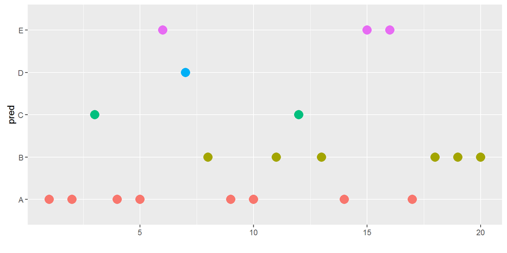